# assignment

## Assignment 2022.April.20

37205054 Maosen Ye

A549 human lung carcinoma cell line were exposed to X-ray, C ion of LET 13 keV/μm, and C ion of LET 70 keV/μm in aerobic and hypoxic condition. Survival fractions were measured for multiple dose of each radiation types. Standard deviations, SDs are also indicated and are from three independent experiments.

[figure not shown]

#### A) Draw a set of survival curves exposed in aerobic and hypocix condiction for each radiation types

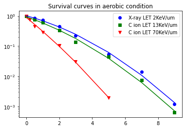

```
xray aerobic prediction standard error: 0.025478108961610724
let13 aerobic prediction standard error: 0.03196818019482246
let70 aerobic prediction standard error: 0.06336429877435915
```

```python
import matplotlib.pyplot as plt
import math
import numpy as np

Gy_1_aerobic = np.array([0,0.5,1,2,3,5,7,9])
SF_xray_aerobic = np.array([1,0.85,0.744,0.452,0.2224,0.054,0.014,0.00122])
SF_LEF13_aerobic = np.array([1,0.75,0.61,0.34,0.135,0.044,0.0075,0.00064])
Gy_2_aerobic = np.array([0,0.2,0.5,1,2,3,5])
SF_LEF70_aerobic = np.array([1,0.75,0.45,0.286,0.105,0.0306,0.00194])

#plot and fit the survival curves exposed in aerobic condition
plt.plot(Gy_1_aerobic, SF_xray_aerobic, 'bo', label= "X-ray LET 2KeV/um")
plt.plot(Gy_1_aerobic, SF_LEF13_aerobic, 'gs', label = 'C ion LET 13KeV/um')
plt.plot(Gy_2_aerobic, SF_LEF70_aerobic, 'rv', label='C ion LET 70KeV/um')
plt.yscale("log")
p_xray_aerobic = np.polyfit(Gy_1_aerobic, np.log(SF_xray_aerobic), 2)
p_let13_aerobic = np.polyfit(Gy_1_aerobic, np.log(SF_LEF13_aerobic), 2)
p_let70_aerobic = np.polyfit(Gy_2_aerobic, np.log(SF_LEF70_aerobic), 2)


plt.plot(Gy_1_aerobic, np.exp(np.polyval(p_xray_aerobic, Gy_1_aerobic)), color="blue")
plt.plot(Gy_1_aerobic, np.exp(np.polyval(p_let13_aerobic, Gy_1_aerobic)), color="green")
plt.plot(Gy_2_aerobic, np.exp(np.polyval(p_let70_aerobic, Gy_2_aerobic)), color="red")
plt.title("Survival curves in aerobic condition")
plt.legend()
plt.show()

def StandardError(data,prediction):
    squareSum = np.sum(np.square(data-prediction))
    squareroot = np.sqrt(squareSum/(np.size(data)-2))
    return squareroot

xray_aerobic_predict = np.exp(np.polyval(p_xray_aerobic, Gy_1_aerobic))
let13_aerobic_predict = np.exp(np.polyval(p_let13_aerobic, Gy_1_aerobic))
let70_aerobic_predict = np.exp(np.polyval(p_let70_aerobic, Gy_2_aerobic))
print("xray aerobic prediction standard error:", StandardError(SF_xray_aerobic, xray_aerobic_predict))
print("let13 aerobic prediction standard error:", StandardError(SF_LEF13_aerobic, let13_aerobic_predict))
print("let70 aerobic prediction standard error:", StandardError(SF_LEF70_aerobic, let70_aerobic_predict))
```

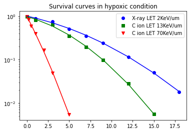

```
xray hypoxic prediction standard error: 0.01912541833567152
let13 hypoxic prediction standard error: 0.030249128881773148
let70 hypoxic prediction standard error: 0.02092843381348444
```

```python
Gy_1_hypoxic = np.array([0,1,3,5,7,9,12,15,18])
Gy_2_hypoxic = np.array([0,1,3,5,7,9,12,15])
Gy_3_hypoxic = np.array([0,0.2,0.5,1,2,3,5])
SF_xray_hypoxic = np.array([1,0.9,0.754,0.51,0.35,0.242,0.115,0.051,0.018])
SF_LEF13_hypoxic = np.array([1,0.813,0.65,0.35,0.198,0.098,0.028,0.0055])
SF_LEF70_hypoxic = np.array([1,0.842,0.595,0.405,0.166,0.0496,0.00534])

#plot and fit the survival curves exposed in aerobic condition
plt.plot(Gy_1_hypoxic, SF_xray_hypoxic, 'bo', label= "X-ray LET 2KeV/um")
plt.plot(Gy_2_hypoxic, SF_LEF13_hypoxic, 'gs', label = 'C ion LET 13KeV/um')
plt.plot(Gy_3_hypoxic, SF_LEF70_hypoxic, 'rv', label='C ion LET 70KeV/um')
plt.yscale("log")
p_xray_hypoxic = np.polyfit(Gy_1_hypoxic, np.log(SF_xray_hypoxic), 2)
p_let13_hypoxic = np.polyfit(Gy_2_hypoxic, np.log(SF_LEF13_hypoxic), 2)
p_let70_hypoxic = np.polyfit(Gy_3_hypoxic, np.log(SF_LEF70_hypoxic), 2)


plt.plot(Gy_1_hypoxic, np.exp(np.polyval(p_xray_hypoxic, Gy_1_hypoxic)), color="blue")
plt.plot(Gy_2_hypoxic, np.exp(np.polyval(p_let13_hypoxic, Gy_2_hypoxic)), color="green")
plt.plot(Gy_3_hypoxic, np.exp(np.polyval(p_let70_hypoxic, Gy_3_hypoxic)), color="red")
plt.title("Survival curves in hypoxic condition")
plt.legend()
plt.show()

xray_hypoxic_predict = np.exp(np.polyval(p_xray_hypoxic, Gy_1_hypoxic))
let13_hypoxic_predict = np.exp(np.polyval(p_let13_hypoxic, Gy_2_hypoxic))
let70_hypoxic_predict = np.exp(np.polyval(p_let70_hypoxic, Gy_3_hypoxic))
print("xray hypoxic prediction standard error:", StandardError(SF_xray_hypoxic, xray_hypoxic_predict))
print("let13 hypoxic prediction standard error:", StandardError(SF_LEF13_hypoxic, let13_hypoxic_predict))
print("let70 hypoxic prediction standard error:", StandardError(SF_LEF70_hypoxic, let70_hypoxic_predict))
```

#### B) Fit the data to LQ-model to obtain the alpha and beta parameter

```python
import tabulate

#print the alpha and beta parameter
alpha_xray_aerobic =round( p_xray_aerobic[0]*1000)/1000*-1
beta_xray_aerobic =round( p_xray_aerobic[1]*1000)/1000*-1
alpha_let13_aerobic = round(p_let13_aerobic[0]*1000)/1000*-1
beta_let13_aerobic = round(p_let13_aerobic[1]*1000)/1000*-1
alpha_let70_aerobic = round(p_let70_aerobic[0]*1000)/1000*-1
beta_let70_aerobic = round(p_let70_aerobic[1]*1000)/1000*-1

alpha_xray_hypoxic = round( p_xray_hypoxic[0]*1000)/1000*-1
beta_xray_hypoxic =round( p_xray_hypoxic[1]*1000)/1000*-1
alpha_let13_hypoxic = round(p_let13_hypoxic[0]*1000)/1000*-1
beta_let13_hypoxic = round(p_let13_hypoxic[1]*1000)/1000*-1
alpha_let70_hypoxic = round(p_let70_hypoxic[0]*1000)/1000*-1
beta_let70_hypoxic = round(p_let70_hypoxic[1]*1000)/1000*-1

data = [["Condition","alpha","beta"],
         ["X-ray LET 2KeV/um (aerobic)",alpha_xray_aerobic,beta_xray_aerobic],
         ["C ion LET 13Ke/um (aerobic)",alpha_let13_aerobic,beta_let13_aerobic],
         ["C ion LET 70Ke/um (aerobic)",alpha_let70_aerobic,beta_let70_aerobic],
         ["X-ray LET 2KeV/um (hypoxic)",alpha_xray_hypoxic,beta_xray_hypoxic],
          ["C ion LET 13Ke/um (hypoxic)",alpha_let13_hypoxic,beta_let13_hypoxic],
         ["C ion LET 70Ke/um (hypoxic)",alpha_let70_hypoxic,beta_let70_hypoxic],]
table = tabulate.tabulate(data, tablefmt='html')
table
```

| Condition | alpha | beta |
| --- | --- | --- |
| X-ray LET 2KeV/um (aerobic) | 0.044 | 0.34 |
| C ion LET 13Ke/um (aerobic) | 0.041 | 0.43 |
| C ion LET 70Ke/um (aerobic) | 0.041 | 1.015 |
| X-ray LET 2KeV/um (hypoxic) | 0.007 | 0.097 |
| C ion LET 13Ke/um (hypoxic) | 0.015 | 0.122 |
| C ion LET 70Ke/um (hypoxic) | 0.037 | 0.862 |

#### C) Use the alpha and beta parameter to calculate the D0, D10, D1

- D1 is the absorbed dose that reduces the number of cells to 37% $(e^{-1})$ of the initial number.
- D10 is the absorbed dose that reduces the population to 10%, which is about 2.3 times of D0
- D0 is the dose required to reduce survival from 0.1 to 0.037 or from 0.01 to 0.0037, and so on.

```python
def solve_quadratic(a,b,c):
    result = (-b+math.sqrt(b**2-4*a*c))/(2*a)
    result = round(result*1000)/1000
    return result

D0_test_aerobic = solve_quadratic(0.231,0.208,-1)
test = (-0.208+math.sqrt(0.208**22+4*0.231))/0.231/2
print(test)

D0_Xray_aerobic = -solve_quadratic(beta_xray_aerobic,alpha_xray_aerobic,math.log(0.1)) + solve_quadratic(beta_xray_aerobic,alpha_xray_aerobic,math.log(0.037))
D10_Xray_aerobic =  D0_Xray_aerobic*2.3
D1_Xray_aerobic =  solve_quadratic(beta_xray_aerobic,alpha_xray_aerobic,-1)

D0_let13_aerobic = -solve_quadratic(beta_let13_aerobic,alpha_let13_aerobic,math.log(0.1)) + solve_quadratic(beta_let13_aerobic,alpha_let13_aerobic,math.log(0.037))
D10_let13_aerobic =  D0_let13_aerobic*2.3
D1_let13_aerobic =  solve_quadratic(beta_let13_aerobic,alpha_let13_aerobic,-1)

D0_let70_aerobic = -solve_quadratic(beta_let70_aerobic,alpha_let70_aerobic,math.log(0.1)) + solve_quadratic(beta_let70_aerobic,alpha_let70_aerobic,math.log(0.037))
D10_let70_aerobic =  D0_let70_aerobic*2.3
D1_let70_aerobic =  solve_quadratic(beta_let70_aerobic,alpha_let70_aerobic,-1)

D0_Xray_hypoxic = -solve_quadratic(beta_xray_hypoxic,alpha_xray_hypoxic,math.log(0.1)) + solve_quadratic(beta_xray_hypoxic,alpha_xray_hypoxic,math.log(0.037))
D10_Xray_hypoxic =  D0_Xray_hypoxic*2.3
D1_Xray_hypoxic =  solve_quadratic(beta_xray_hypoxic,alpha_xray_hypoxic,-1)

D0_let13_hypoxic = -solve_quadratic(beta_let13_hypoxic,alpha_let13_hypoxic,math.log(0.1)) + solve_quadratic(beta_let13_hypoxic,alpha_let13_hypoxic,math.log(0.037))
D10_let13_hypoxic =  D0_let13_hypoxic*2.3
D1_let13_hypoxic =  solve_quadratic(beta_let13_hypoxic,alpha_let13_hypoxic,-1)

D0_let70_hypoxic = -solve_quadratic(beta_let70_hypoxic,alpha_let70_hypoxic,math.log(0.1)) + solve_quadratic(beta_let70_hypoxic,alpha_let70_hypoxic,math.log(0.037))
D10_let70_hypoxic =  D0_let70_hypoxic*2.3
D1_let70_hypoxic =  solve_quadratic(beta_let70_hypoxic,alpha_let70_hypoxic,-1)

data = [["Condition","alpha","beta","D0", "D10","D1"],
         ["X-ray LET 2KeV/um (aerobic)",alpha_xray_aerobic,beta_xray_aerobic, D0_Xray_aerobic, D10_Xray_aerobic, D1_Xray_aerobic],
         ["C ion LET 13Ke/um (aerobic)",alpha_let13_aerobic,beta_let13_aerobic, D0_let13_aerobic, D10_let13_aerobic, D1_let13_aerobic,],
         ["C ion LET 70Ke/um (aerobic)",alpha_let70_aerobic,beta_let70_aerobic, D0_let70_aerobic, D10_let70_aerobic, D1_let70_aerobic],
         ["X-ray LET 2KeV/um (hypoxic)",alpha_xray_hypoxic,beta_xray_hypoxic,D0_Xray_hypoxic, D10_Xray_hypoxic, D1_Xray_hypoxic,],
          ["C ion LET 13Ke/um (hypoxic)",alpha_let13_hypoxic,beta_let13_hypoxic,D0_let13_hypoxic, D10_let13_hypoxic, D1_let13_hypoxic,],
         ["C ion LET 70Ke/um (hypoxic)",alpha_let70_hypoxic,beta_let70_hypoxic,D0_let70_hypoxic, D10_let70_hypoxic, D1_let70_hypoxic,],]
table = tabulate.tabulate(data, tablefmt='html')
table
```

```
1.6304094962247486
```

| Condition | alpha | beta | D0 | D10 | D1 |
| --- | --- | --- | --- | --- | --- |
| X-ray LET 2KeV/um (aerobic) | 0.044 | 0.34 | 0.512 | 1.1776 | 1.652 |
| C ion LET 13Ke/um (aerobic) | 0.041 | 0.43 | 0.45500000000000007 | 1.0465 | 1.478 |
| C ion LET 70Ke/um (aerobic) | 0.041 | 1.015 | 0.29600000000000004 | 0.6808000000000001 | 0.973 |
| X-ray LET 2KeV/um (hypoxic) | 0.007 | 0.097 | 0.9579999999999993 | 2.203399999999998 | 3.175 |
| C ion LET 13Ke/um (hypoxic) | 0.015 | 0.122 | 0.8539999999999992 | 1.964199999999998 | 2.802 |
| C ion LET 70Ke/um (hypoxic) | 0.037 | 0.862 | 0.32099999999999995 | 0.7382999999999998 | 1.056 |

```python
data = [["Condition","alpha","beta","D0", "D10","D1"],
         ["X-ray LET 2KeV/um (aerobic)",alpha_xray_aerobic,beta_xray_aerobic, 1,1,1],
         ["C ion LET 13Ke/um (aerobic)",alpha_let13_aerobic,beta_let13_aerobic, D0_Xray_aerobic/D0_let13_aerobic, D10_Xray_aerobic/D10_let13_aerobic, D1_Xray_aerobic/D1_let13_aerobic,],
         ["C ion LET 70Ke/um (aerobic)",alpha_let70_aerobic,beta_let70_aerobic, D0_Xray_aerobic/D0_let70_aerobic, D10_Xray_aerobic/D10_let70_aerobic, D1_Xray_aerobic/D1_let70_aerobic],
         ["X-ray LET 2KeV/um (hypoxic)",alpha_xray_hypoxic,beta_xray_hypoxic,1,1,1],
          ["C ion LET 13Ke/um (hypoxic)",alpha_let13_hypoxic,beta_let13_hypoxic,D0_Xray_hypoxic/D0_let13_hypoxic, D10_Xray_hypoxic/D10_let13_hypoxic, D1_Xray_hypoxic/D1_let13_hypoxic,],
         ["C ion LET 70Ke/um (hypoxic)",alpha_let70_hypoxic,beta_let70_hypoxic,D0_Xray_hypoxic/D0_let70_hypoxic, D10_Xray_hypoxic/D10_let70_hypoxic, D1_Xray_hypoxic/D1_let70_hypoxic,],]
table = tabulate.tabulate(data, tablefmt='html')
table
```

| Condition | alpha | beta | D0 | D10 | D1 |
| --- | --- | --- | --- | --- | --- |
| X-ray LET 2KeV/um (aerobic) | 0.044 | 0.34 | 1 | 1 | 1 |
| C ion LET 13Ke/um (aerobic) | 0.041 | 0.43 | 1.125274725274725 | 1.1252747252747253 | 1.1177266576454667 |
| C ion LET 70Ke/um (aerobic) | 0.041 | 1.015 | 1.7297297297297296 | 1.7297297297297296 | 1.697841726618705 |
| X-ray LET 2KeV/um (hypoxic) | 0.007 | 0.097 | 1 | 1 | 1 |
| C ion LET 13Ke/um (hypoxic) | 0.015 | 0.122 | 1.1217798594847777 | 1.1217798594847777 | 1.1331192005710207 |
| C ion LET 70Ke/um (hypoxic) | 0.037 | 0.862 | 2.9844236760124594 | 2.984423676012459 | 3.0066287878787876 |

```python
data = [["Condition", "OER(D10)","OER(D1)","OER(D10)"],
         ["X-ray LET 2KeV/um", D0_Xray_hypoxic/D0_Xray_aerobic, D10_Xray_hypoxic/D10_Xray_aerobic, D1_Xray_hypoxic/D1_Xray_aerobic],
         ["C ion LET 13Ke/um", D0_let13_hypoxic/D0_let13_aerobic, D10_let13_hypoxic/D10_let13_aerobic, D1_let13_hypoxic/D1_let13_aerobic],
         ["C ion LET 70Ke/um", D0_let70_hypoxic/D0_let70_aerobic, D10_let70_hypoxic/D10_let70_aerobic, D1_let70_hypoxic/D1_let70_aerobic]
        ]
table = tabulate.tabulate(data, tablefmt='html')
table
```

[output not shown]

#### F) Have all the parameters (with standard error) summarized in a Table.

[figure not shown]